# CIÊNCIA DE DADOS - ESTÁGIO HOME OFFICE

luisotavio.pro

11/04/2021

### Projeto luisotavio.pro

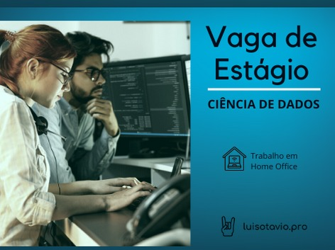

A Ciência de Dados tem mudado drasticamente o mercado mundial. Seja com a criação de produtos baseados em inteligência artificial guiada por dados, por otimizações que resultam em benefícios para o consumidor ou economia para as empresas.

Diante dessa nova realidade, o objetivo do projeto luisotavio.pro é **disseminar o conhecimento de Ciência de Dados para os futuros profissionais do Brasil**.

O projeto se iniciou em 2020 e conta com os seguintes canais para propagação dos conteúdos de Ciências de Dados: [Youtube](https://www.youtube.com/channel/UCC3Vw7R-fKS-uYXYRhJ983A), [Instagram](https://www.instagram.com/luisotavio.pro/), [blog](http://www.luisotavio.pro) e curso.

Um pilar do projeto é sempre trazer conhecimentos práticos para seu público e que possam ser imediatamente aplicados a casos reais.

Para atender ao crescimento e às ambições do projeto, precisamos de um(a) colaborador(a) na área técnica do projeto.

### Principais atividades da vaga:

✅ Produção de conteúdo de Estatística e Ciência de Dados para o blog luisotavio.pro

✅ Produção de material complementar para o curso Ciência de Dados: do zero ao pro.

✅ Auxiliar na produção de conteúdo para as redes sociais.

✅ Participar diretamente na criação de novos produtos.

### Requisitos técnicos para a vaga:

✅ Boa capacidade de escrita

✅ Conhecimento de Estatística

👉 É desejável que o candidato tenha conhecimento de probabilidade, testes estatísticos e análise de regressão. Será um diferencial caso domine os conteúdos de Estatística Multivariada e Modelos Lineares Generalizados.

✅ Linguagem R

👉 É desejável que o candidato tenha domínio básico da linguagem R e conheça as seguintes bibliotecas: `dplyr`, `ggplot` e `rmarkdown`.

✅ Bom nível de entendimento de textos e vídeos em inglês.

✅ Disponibilidade para cumprir pelo menos 1 ano de Estágio

### Horário de trabalho: a combinar (30 horas semanais)

### Bolsa Estágio: R$ 1500,00

**Se você se interessa por Ciência de Dados, tem muita disciplina e quer fazer a diferença no mercado de educação para Ciência de dados, essa vaga é para você!**

### 👉 Envie o seu currículo ou portfólio para **contato@luisotavio.pro** com o assunto “ESTÁGIO”.